# Exploring the BRFSS data

## Setup

### Load packages

```r
library(ggplot2)
library(dplyr)
```

### Load data

```r
load("brfss2013.RData")
```

## Part 1: Data

The Behavior Risk Factor Surveillance System(BRFSS) is a telephone-based survey that collect health-related data about US residents across the country, including their health-related risk behaviors, chronic health conditions and use of preventive services. It was initiated in 1984 with 15 states, and expanded overtime to include all 50 states, the District of Columbia, Puerto Rico, and Guam collect data annually, as well as American Samoa, Federated States of Micronesia, and Palau collect survey data over a limited point- in-time. It is the largest continuously conducted health survey system in the world.

**Data Collection** The BFRSS data were collected by conducting both landline telephone-based and cellular telephone-based (starting 2011) surveys. In landline telephone surveys, data were collected from a randomly selected adult in a household using Disproportionate Stratified Sampling (DSS). In cellular telephone-based survey, randomly selected adult respondents who reside in private residence or college housing participated the survey by using cellular phone for interview.

**casaulity** The BRFSS data is observational, not experimental, therefore it can only be used to establish correlation between variables, but not casuality.

## Part 2: Research questions

**Research quesion 1:** What is the relationship between sleep time and general health based on gender?

**Research quesion 2:** Does people’s education and income level have correlation with HPV vaccination ratio?

**Research quesion 3:** How residents in different states differ in amount of time spent on physical activity?

## Part 3: Exploratory data analysis

**Research quesion 1:** What is the relationship between sleep time and general health based on gender?

```r
df1 <- select(brfss2013, genhlth, sleptim1, sex) %>%
  filter(!is.na(genhlth),!is.na(sex),sleptim1 <=24)
summary(df1)
```

```
##       genhlth          sleptim1          sex
##  Excellent: 84821   Min.   : 1.000   Male  :198148
##  Very good:157832   1st Qu.: 6.000   Female:284455
##  Good     :148299   Median : 7.000
##  Fair     : 65012   Mean   : 7.051
##  Poor     : 26639   3rd Qu.: 8.000
##                     Max.   :24.000
```

```r
df1 %>%
  group_by(sleptim1) %>%
  summarise(count=n())
```

```
## # A tibble: 24 x 2
##    sleptim1  count
##       <int>  <int>
##  1        1    228
##  2        2   1063
##  3        3   3466
##  4        4  14194
##  5        5  33290
##  6        6 105880
##  7        7 142090
##  8        8 140497
##  9        9  23688
## 10       10  12030
## # ... with 14 more rows
```

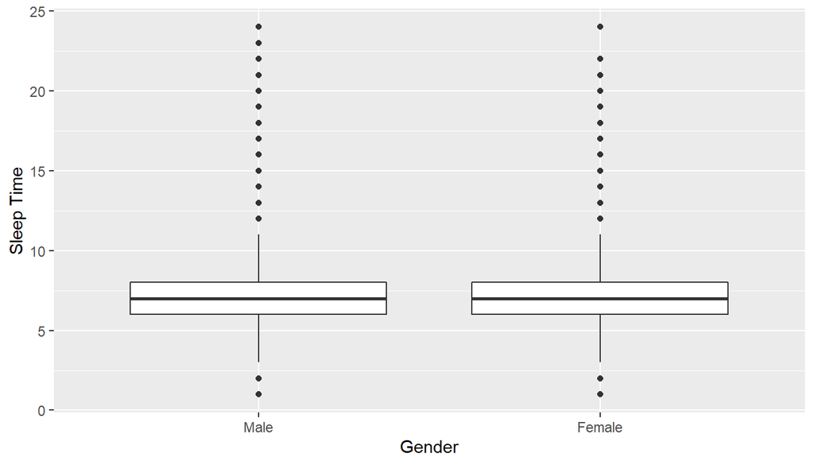

```r
ggplot(df1, aes(x = sex, y = sleptim1)) +
  geom_boxplot() +
  xlab("Gender") + ylab("Sleep Time")
```

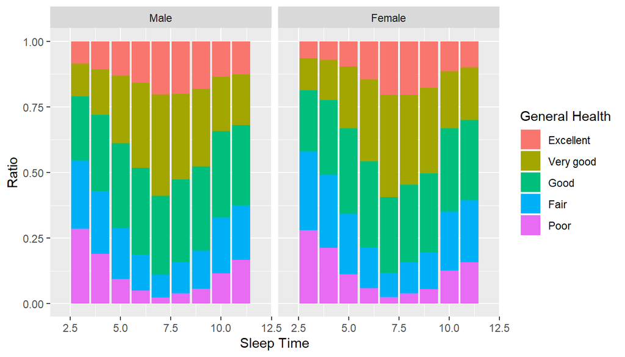

```r
ggplot(df1, aes(x = sleptim1, fill = genhlth)) +
  geom_bar(position = "fill") + facet_grid(. ~ sex) +
  xlab("Sleep Time") + ylab("Ratio") + xlim(2,12) + scale_fill_discrete(name = "General Health")
```

Based on this information, only sleep time 3-11 hours are included in the bar graph to look at relationship between sleep time and general health condition based on gender. Again, gender difference is not obvious. However, there is clear correlation between sleep time and general health condition. People with 7-8 hours of sleep report the highest ratio of good-to-excellent general health conditions, while lower or higher amount of sleep correlates with decreasing ratio of good-to-excellent general health conditions.

**Research quesion 2:** Does people’s education and income level have correlation with HPV vaccination ratio?

```r
income <- brfss2013$income2
income <- as.character(income)
income[income == "Less than $10,000"] <- "<10K"
income[income == "Less than $15,000"] <- "<15K"
income[income == "Less than $20,000"] <- "<20K"
income[income == "Less than $25,000"] <- "<25K"
income[income == "Less than $35,000"] <- "<35K"
income[income == "Less than $50,000"] <- "<50K"
income[income == "Less than $75,000"] <- "<75k"
income[income == "$75,000 or more"] <- ">75k"

df2 <- select(brfss2013, income2, educa, hpvadvc2)
summary(df2)
```

```
##               income2
##  $75,000 or more  :115902
##  Less than $75,000: 65231
##  Less than $50,000: 61509
##  Less than $35,000: 48867
##  Less than $25,000: 41732
##  (Other)          : 87108
##  NA's             : 71426
##                                                           educa
##  Never attended school or only kindergarten                  :   677
##  Grades 1 through 8 (Elementary)                             : 13395
##  Grades 9 though 11 (Some high school)                       : 28141
##  Grade 12 or GED (High school graduate)                      :142971
##  College 1 year to 3 years (Some college or technical school):134197
##  College 4 years or more (College graduate)                  :170120
##  NA's                                                        :  2274
##                       hpvadvc2
##  Yes                      :  1362
##  No                       : 11714
##  Doctor refused when asked:    22
##  NA's                     :478677
##
##
##
```

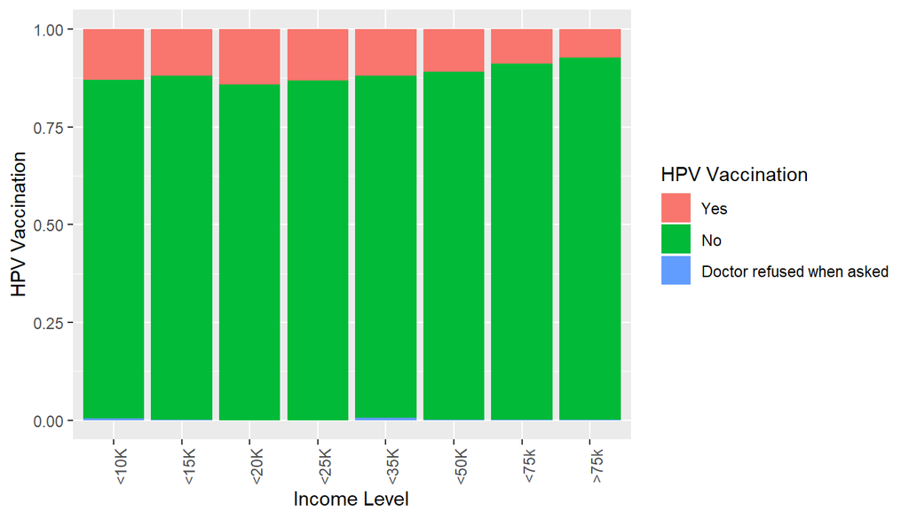

```r
df2 <- cbind(df2, income)%>%
  filter(!is.na(income),!is.na(educa), !is.na(hpvadvc2))


ggplot(df2, aes(x = income, fill = hpvadvc2)) +
  geom_bar(position = "fill") +
  xlab("Income Level") + ylab("HPV Vaccination") +
  theme(axis.text.x = element_text(angle=90, hjust=0.95)) + scale_fill_discrete(name = "HPV Vaccination")
```

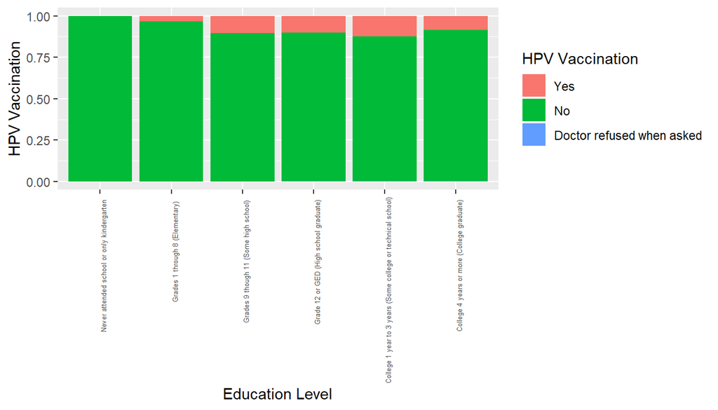

```r
ggplot(df2, aes(x = educa, fill = hpvadvc2)) +
  geom_bar(position = "fill") +
  xlab("Education Level") + ylab("HPV Vaccination") +
  theme(axis.text.x = element_text(size = 5, angle=90, hjust=0.95)) + scale_fill_discrete(name = "HPV Vaccination")
```

The 1st graph plots HPV vaccination based on income level. It shows people with highest income actually has lowest ratio of HPV vaccination. People in the income bracket of (15-20K) has the highest ratio of HPV vaccination. The 2nd graph shows people with higher education level tends to have higher ratio of HPV vaccination, except for college graduates, which has lower HPV vaccination ratio than 3 other groups: “some high school”, “high school graduate” and “some college or technical school”. To further understand this somewhat unexpected outcome, I decide to look at relationship between income and education level:

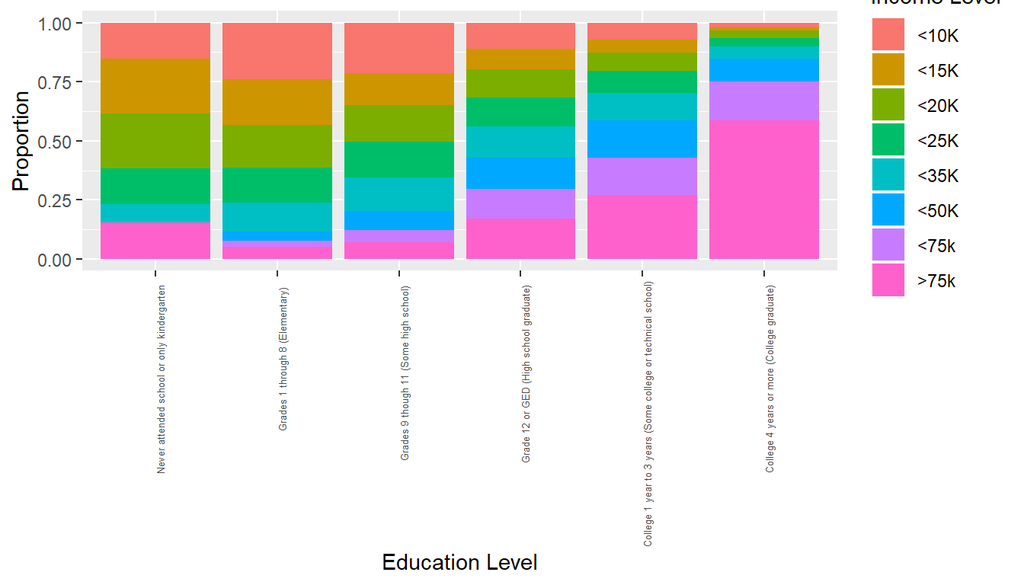

```r
ggplot(df2, aes(x = educa, fill = income)) +
         geom_bar(position = "fill") +
  xlab("Education Level") + ylab("Proportion") +
  theme(axis.text.x = element_text(size = 5, angle=90, hjust=0.95)) +
  scale_fill_discrete(name = "Income Level")
```

The 3rd graph shows strong positive correlation between education level and income level. Note that the group “college graduate”， which has relatively low HPV vaccination ratio showing in 2nd graph, has the highest proportion of people with 50-75K and >75K income compared to other education levels. These are the two income groups also has lowest HPV vaccination ratio, based on 1st graph.

**Research quesion 3:** How residents in different states differ in amount of time spent on physical activity?

```r
df3 <- select(brfss2013, pa1min_, X_state) %>%
  filter(!is.na(pa1min_))

summary(df3)
```

```
##     pa1min_                 X_state
##  Min.   :    0.0   Florida      : 20951
##  1st Qu.:  109.0   Kansas       : 15762
##  Median :  240.0   Nebraska     : 11481
##  Mean   :  440.1   Minnesota    : 10176
##  3rd Qu.:  495.0   Colorado     :  9772
##  Max.   :81238.0   Massachusetts:  9757
##                    (Other)      :245915
```

```r
quantile(df3$pa1min_, c(.05, .10, .25, .50,  .75, .90, .95))
```

```
##   5%  10%  25%  50%  75%  90%  95%
##    0   40  109  240  495  960 1500
```

Here I use pa1min_ (Minutes Of Total Physical Activity Per Week) as a measurement for participation in physical activity. As shown in summary, the amount of time people spent in physical activity vary greatly. Therefore I decide to only use 10% to 90% quantile of the data (40-960 min per week) to plot the distribution of physical activity for each state.

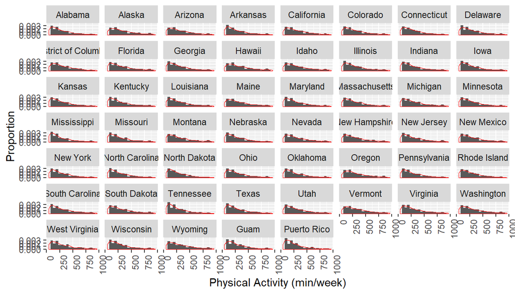

```r
ggplot(df3, aes(pa1min_, ..density..))+
  geom_histogram(binwidth = 50)+
  facet_wrap(~X_state)+
  geom_density(col = "red", lwd = 0.01)+
  xlab("Physical Activity (min/week)") + ylab("Proportion") + xlim(40,960) +
  theme(axis.text.x = element_text(angle=90, hjust=0.95))
```

The distribution curves are all rightly skewed, which is expected, since most people only do physical activity occasionally. By looking at the shape of distribution, it’s obvious that some states are more severely rightly skewed while others tend to spread wider, suggesting residents in some states overal participate in physical activity less than other states. To obtain quantitative insights into on average how long residents in each states spend on physical activity, I calculate the mean and median for each state.

```r
ddf3 <- df3 %>%
  group_by(X_state) %>%
  summarise(pamean = mean(pa1min_), pamedian = median(pa1min_))
ddf3%>%View
```

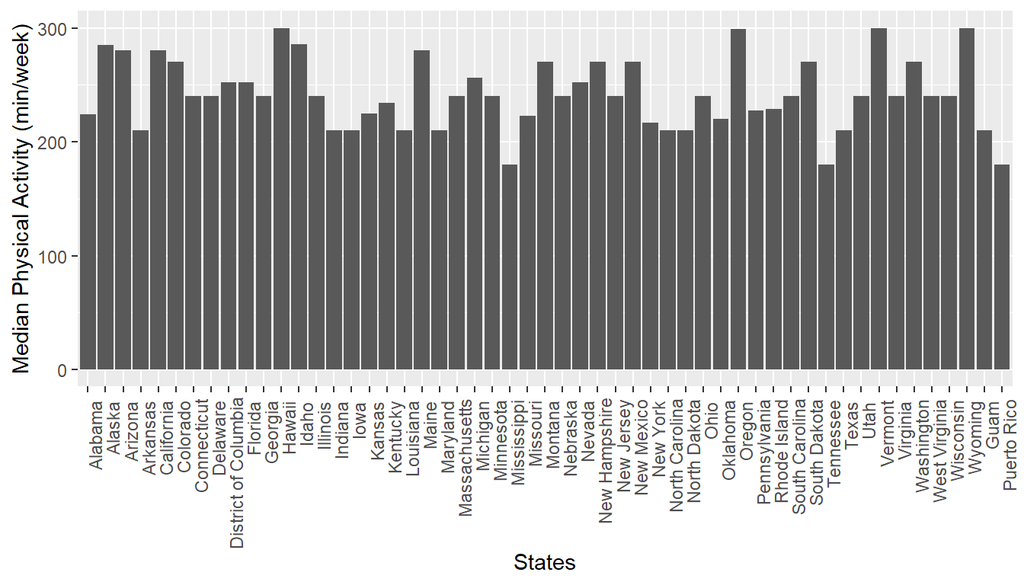

```r
ggplot(ddf3, aes(x = X_state, y = pamedian))+
  geom_bar(stat = "identity") +
  xlab("States") + ylab("Median Physical Activity (min/week)")  +
  theme(axis.text.x = element_text(angle=90, hjust=0.95))
```